# Perception of Corruption - Analysis Project

Author

Marshall Prizio

## Executive Summary

This project investigates individual perceptions of corruption across nations using Wave 7 data from the World Values Survey (WVS) merged with macroeconomic indicators from the World Bank Development Indicators. Through data cleaning, tidy reshaping, relational joins, and hypothesis-driven visualizations, this report evaluates how demographic, institutional, and socioeconomic factors shape citizen perceptions of governance. Additionally, it examines the longitudinal macroeconomic trajectory of Afghanistan (2000–2023). Key findings are summarized in Section 8.

## 1. Packages

```r
library(tidyverse)
library(ggplot2)
library(stringr)
library(maps)
library(here)
```

## 2. Data Cleaning & Feature Engineering

This pipeline filters primary tracking columns, renames variable identifiers, re-codes special survey non-response values (`-1`, `-2`, `-4`, `-5`) to `NA`, engineers an ordinal age category, and isolates the 2020 WVS cross-section.

```r
# Load raw survey data
WVS <- readRDS(here("Data", "WVS_W7.rds"))

# Subset, rename, recode missing values, and bin age categories
WVS_subset <- WVS |>
  select(A_YEAR, B_COUNTRY_ALPHA, D_INTERVIEW, Q260, Q262, Q275R, Q112) |>
  rename(
    sex = Q260,
    age = Q262,
    education = Q275R,
    corruption_perception = Q112
  ) |>
  mutate(across(everything(), ~ ifelse(. %in% c(-1, -2, -4, -5), NA, .))) |>
  mutate(age_category = case_when(
    age >= 16 & age <= 29 ~ "young",
    age >= 30 & age <= 49 ~ "middle",
    age >= 50             ~ "senior",
    TRUE                  ~ NA_character_
  ))

# Filter for target survey wave (2020)
WVS_clean <- WVS_subset |> filter(A_YEAR == 2020)
```

```r
WVS_clean |>
  summarise(respondents = n(), countries = n_distinct(B_COUNTRY_ALPHA))
```

```
  respondents countries
1       21187        14
```

**Interpretation & Methodological Notes**

- **Data Integrity:** Survey non-response codes are systematically converted to `NA` values to ensure missing data does not distort numeric summaries or graphical distributions.
- **Feature Engineering:** Continuous age observations are grouped into life-stage categories (young, middle, senior) to enable demographic subgroup comparisons.
- **Sample Scope:** The 2020 cross-section contains 21,187 respondents from only 14 countries (Canada, Ethiopia, Guatemala, Iran, Kyrgyz Republic, Myanmar, Mongolia, Nicaragua, New Zealand, Singapore, Tajikistan, Ukraine, Viet Nam, and Zimbabwe). Country-level results below are therefore based on 14 observations.

## 3. World Bank Data Reshaping & Data Joining

World Bank macroeconomic indicator datasets are delivered in a wide format. This step reshapes the data into tidy country-year observations via double pivoting (`pivot_longer()` and `pivot_wider()`), converts the World Bank’s `..` missing-value placeholders to numeric `NA`, and performs a relational `left_join()` with the cleaned WVS survey observations.

```r
# Load World Bank data
corruption <- read.csv(here("Data", "WorldBank_corruption.csv"))

# Reshape wide year columns into long format, then pivot indicator series wide
WB_clean <- corruption |>
  pivot_longer(
    cols = starts_with("X"),
    names_to = "year",
    values_to = "value"
  ) |>
  mutate(year = as.integer(str_remove(year, "X"))) |>
  pivot_wider(
    names_from = Series.Name,
    values_from = value
  ) |>
  # World Bank marks missing values with "..", so convert indicators to numeric
  mutate(across(-c(Country.Name, Country.Code, year),
                ~ suppressWarnings(as.numeric(.x))))

# Relational join keyed on ISO country code and survey year
WVS_WB <- WVS_clean |>
  left_join(WB_clean, by = c("B_COUNTRY_ALPHA" = "Country.Code", "A_YEAR" = "year"))

# Join check: how many survey countries received a World Bank value?
WVS_WB |>
  distinct(B_COUNTRY_ALPHA, ControlCorruption) |>
  summarise(countries = n(), matched = sum(!is.na(ControlCorruption)))
```

```
  countries matched
1        14      14
```

**Interpretation & Methodological Notes**

- **Tidy Data Principles:** Pivoting converts annual series headers into explicit observation rows, creating a structured dataset where each row represents a unique country-year observation and each column represents a distinct macroeconomic indicator.
- **Relational Merging:** The `left_join()` anchors on the individual survey responses, mapping country-level indicators (e.g., `ControlCorruption`) to every respondent based on their ISO-3 country code (`B_COUNTRY_ALPHA`) and survey year. The join check confirms that all 14 survey countries matched a World Bank value.
- **Why ISO codes, not COW codes:** The WVS also provides Correlates of War codes (`C_COW_ALPHA`), but the World Bank uses ISO-3 codes, and the two systems differ for many countries. In the 2020 data, the WVS labels Mongolia `MNE` in its COW column, which is Montenegro’s ISO code, so a join on COW codes silently attaches Montenegro’s indicators to Mongolia. Joining on `B_COUNTRY_ALPHA` avoids this.

## 4. Hypothesis 1: Demographic Differences in Corruption Perception (Sex)

**Hypothesis:** Male respondents tend to report higher corruption perception scores than female respondents.

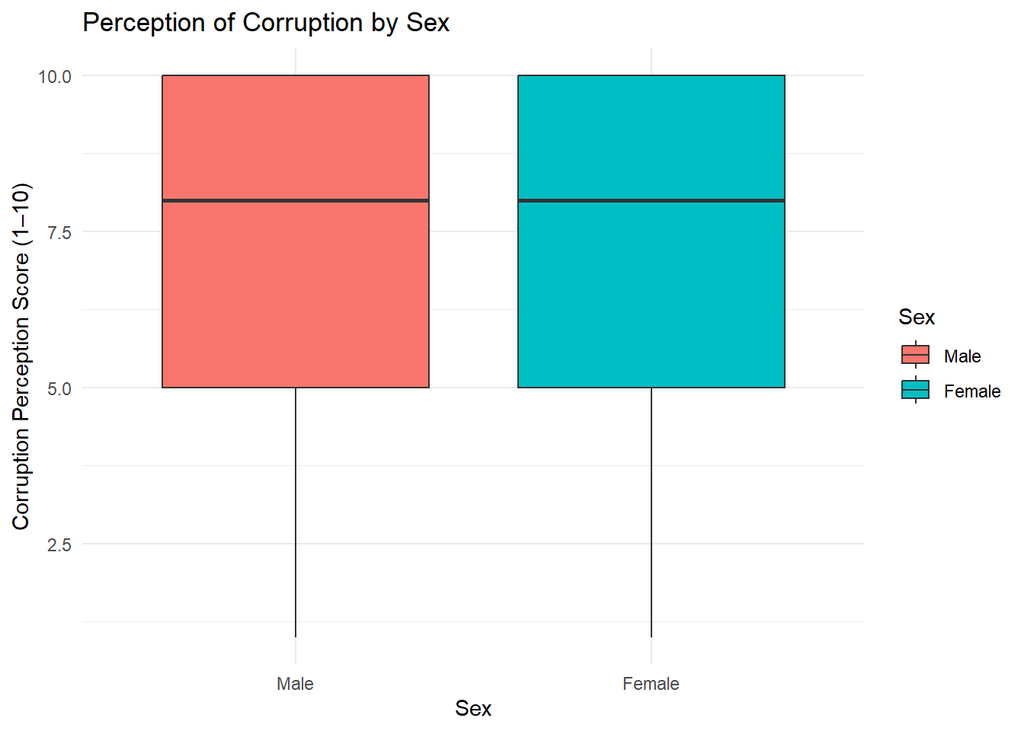

Figure 1: Distribution of corruption perception scores by respondent sex.

```r
WVS_WB |>
  filter(!is.na(sex), !is.na(corruption_perception)) |>
  mutate(sex = factor(sex, levels = c(1, 2), labels = c("Male", "Female"))) |>
  ggplot(aes(x = sex, y = corruption_perception, fill = sex)) +
  geom_boxplot() +
  labs(
    title = "Perception of Corruption by Sex",
    x = "Sex",
    y = "Corruption Perception Score (1–10)",
    fill = "Sex"
  ) +
  theme_minimal()
```

```r
sex_data <- WVS_WB |>
  filter(!is.na(sex), !is.na(corruption_perception)) |>
  mutate(sex = factor(sex, levels = c(1, 2), labels = c("Male", "Female")))

sex_data |>
  group_by(sex) |>
  summarise(n = n(), mean = mean(corruption_perception), sd = sd(corruption_perception))
```

```
# A tibble: 2 × 4
  sex        n  mean    sd
  <fct>  <int> <dbl> <dbl>
1 Male    9999  7.09  2.76
2 Female 10859  7.10  2.74
```

```r
t.test(corruption_perception ~ sex, data = sex_data)
```

```
    Welch Two Sample t-test

data:  corruption_perception by sex
t = -0.18819, df = 20687, p-value = 0.8507
alternative hypothesis: true difference in means between group Male and group Female is not equal to 0
95 percent confidence interval:
 -0.08177297  0.06744641
sample estimates:
  mean in group Male mean in group Female
            7.092109             7.099272
```

**Interpretation**

- **Generalization:** The empirical distribution demonstrates no meaningful difference in perceived corruption between male and female respondents.
- **Examples:** Both groups exhibit identical median corruption perception scores (8 out of 10) and identical interquartile ranges (5 to 10). Mean scores are 7.09 for men and 7.10 for women, a difference of −0.01 points (Welch *t*-test: 95% CI −0.08 to 0.07, *p* = 0.85).
- **Exceptions:** The whiskers extend down to the lowest scores for both groups, indicating that individual variance within each sex far exceeds any difference between them.
- **Hypothesis Evaluation: Not Supported.** Sex does not serve as a determinant of individual corruption perception in this cross-national sample.

## 5. Hypothesis 2: Institutional Control vs. National Perceived Corruption

**Hypothesis:** Countries with higher levels of institutional control of corruption exhibit lower average corruption perception among citizens.

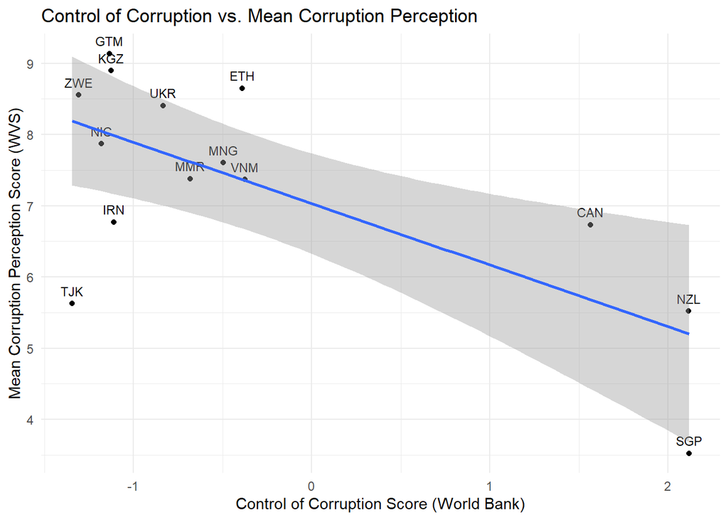

Figure 2: Scatter plot of World Bank Control of Corruption vs. mean WVS perceived corruption (one point per country, 2020).

```r
country_level <- WVS_WB |>
  filter(!is.na(corruption_perception), !is.na(ControlCorruption)) |>
  mutate(ControlCorruption = as.numeric(ControlCorruption)) |>
  filter(!is.na(ControlCorruption)) |>
  group_by(B_COUNTRY_ALPHA) |>
  summarise(
    mean_corruption_perception = mean(corruption_perception, na.rm = TRUE),
    ControlCorruption = first(ControlCorruption)
  )

country_level |>
  ggplot(aes(x = ControlCorruption, y = mean_corruption_perception)) +
  geom_point() +
  geom_text(aes(label = B_COUNTRY_ALPHA), vjust = -0.8, size = 3) +
  geom_smooth(method = "lm", se = TRUE) +
  labs(
    title = "Control of Corruption vs. Mean Corruption Perception",
    x = "Control of Corruption Score (World Bank)",
    y = "Mean Corruption Perception Score (WVS)"
  ) +
  theme_minimal()
```

```r
cor.test(country_level$ControlCorruption, country_level$mean_corruption_perception)
```

```
    Pearson's product-moment correlation

data:  country_level$ControlCorruption and country_level$mean_corruption_perception
t = -3.3338, df = 12, p-value = 0.005956
alternative hypothesis: true correlation is not equal to 0
95 percent confidence interval:
 -0.8947959 -0.2576402
sample estimates:
       cor
-0.6934289
```

```r
cor.test(country_level$ControlCorruption, country_level$mean_corruption_perception,
         method = "spearman")
```

```
    Spearman's rank correlation rho

data:  country_level$ControlCorruption and country_level$mean_corruption_perception
S = 680, p-value = 0.07498
alternative hypothesis: true rho is not equal to 0
sample estimates:
       rho
-0.4945055
```

**Interpretation**

- **Generalization:** Across the 14 countries surveyed in 2020, countries with stronger institutional control of corruption report lower average perceived corruption (Pearson *r* = −0.69, 95% CI −0.89 to −0.26, *p* = 0.006).
- **Examples:** Among the 11 countries with weaker control (scores from about −1.4 to −0.4), mean perception is mostly high, for example 8.6 to 9.1 in Zimbabwe, Kyrgyz Republic, and Guatemala. The three countries with strong control (Canada, New Zealand, and Singapore, scores of about +1.6 to +2.1) report 6.7, 5.5, and 3.5.
- **Exceptions:** Tajikistan has weak control (−1.35) but relatively low perceived corruption (5.6), and Iran is also lower than most weak-control countries (6.8). The sample also has a gap: no countries fall between −0.4 and +1.6, so the fitted line leans heavily on the three high-control countries. A rank-based correlation is weaker (Spearman ρ = −0.49, *p* ≈ 0.07).
- **Hypothesis Evaluation: Supported, with caution.** The direction and strength match the hypothesis, but with only 14 countries and a clustered distribution, the result is suggestive rather than conclusive.

## 6. Case Study: Longitudinal Macroeconomic Trajectory of Afghanistan (2000–2023)

This case study examines a country whose economy and governance both changed sharply between 2000 and 2023, using World Bank indicators to place the cross-national patterns above in the context of a single country over time. It tracks three indicators: GDP level, annual GDP growth, and the World Bank Control of Corruption score.

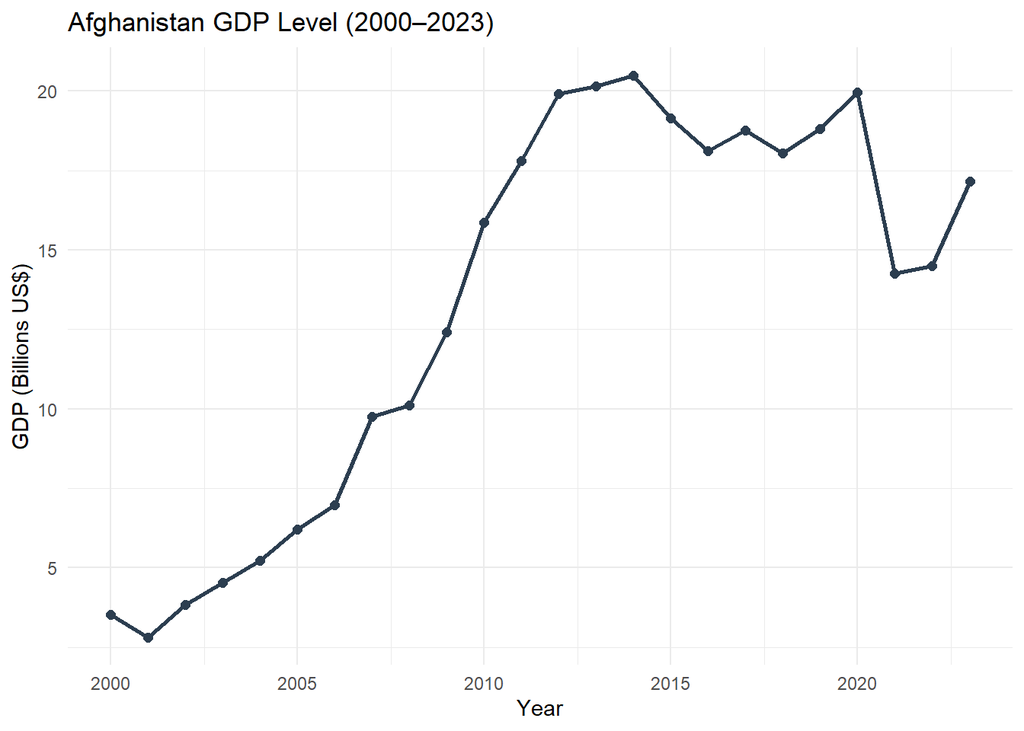

Figure 3: Afghanistan total GDP (billions of current US dollars), 2000–2023.

```r
# Chart 1: Total GDP
p1 <- WB_clean |>
  filter(Country.Name == "Afghanistan", year >= 2000, year <= 2023) |>
  mutate(GDP = as.numeric(GDP) / 1e9) |>
  filter(!is.na(GDP)) |>
  ggplot(aes(x = year, y = GDP)) +
  geom_line(color = "#2c3e50", linewidth = 1) +
  geom_point(color = "#2c3e50", size = 2) +
  labs(
    title = "Afghanistan GDP Level (2000–2023)",
    x = "Year",
    y = "GDP (Billions US$)"
  ) +
  theme_minimal()

p1
```

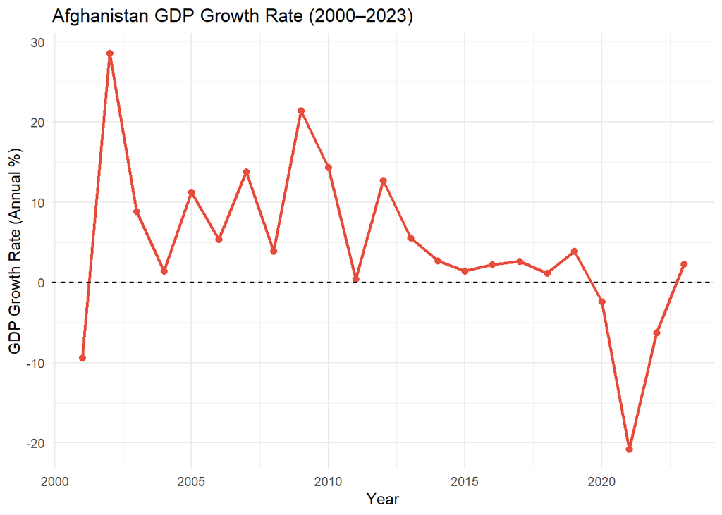

Figure 4: Afghanistan annual GDP growth rate (%), 2000–2023.

```r
# Chart 2: Annual GDP Growth Rate
p2 <- WB_clean |>
  filter(Country.Name == "Afghanistan", year >= 2000, year <= 2023) |>
  mutate(GDPgr = as.numeric(GDPgr)) |>
  filter(!is.na(GDPgr)) |>
  ggplot(aes(x = year, y = GDPgr)) +
  geom_line(color = "#e74c3c", linewidth = 1) +
  geom_point(color = "#e74c3c", size = 2) +
  geom_hline(yintercept = 0, linetype = "dashed", color = "black") +
  labs(
    title = "Afghanistan GDP Growth Rate (2000–2023)",
    x = "Year",
    y = "GDP Growth Rate (Annual %)"
  ) +
  theme_minimal()

p2
```

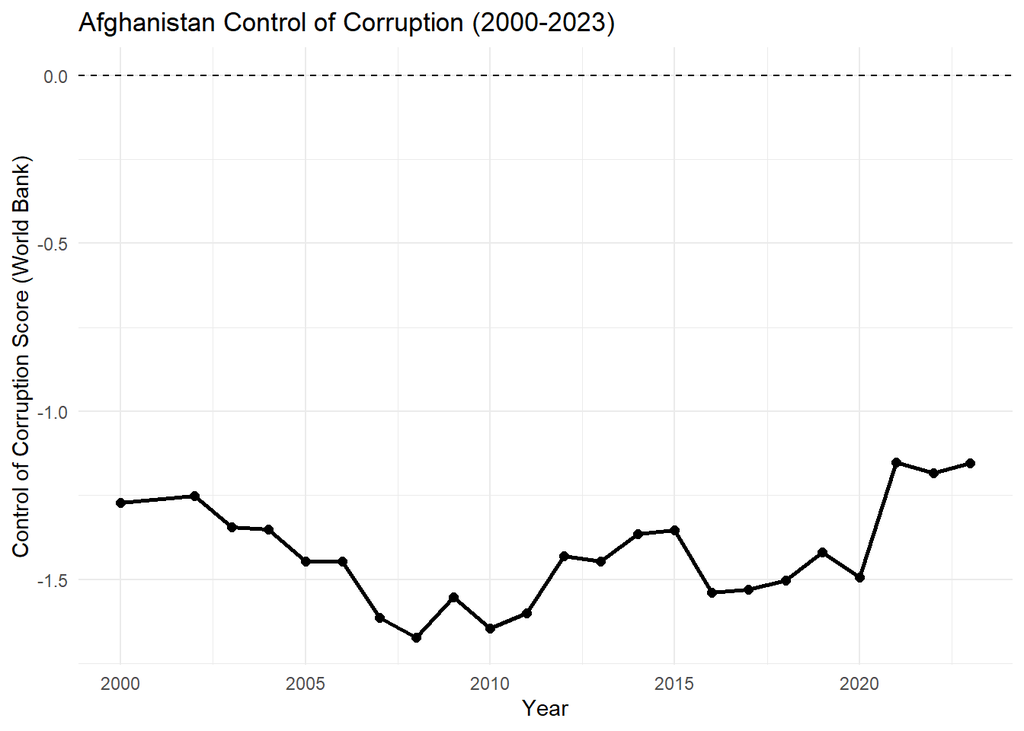

Figure 5: Afghanistan World Bank Control of Corruption score, 2000–2023 (higher values indicate stronger control).

```r
# Chart 3: Control of Corruption
WB_clean |>
  filter(Country.Name == "Afghanistan", year >= 2000, year <= 2023) |>
  mutate(ControlCorruption = as.numeric(ControlCorruption)) |>
  filter(!is.na(ControlCorruption)) |>
  ggplot(aes(x = year, y = ControlCorruption)) +
  geom_line(linewidth = 1) +
  geom_point(size = 2) +
  geom_hline(yintercept = 0, linetype = "dashed") +
  labs(
    title = "Afghanistan Control of Corruption (2000-2023)",
    x = "Year",
    y = "Control of Corruption Score (World Bank)"
  ) +
  theme_minimal()
```

**Interpretation**

- **Generalization:** Afghanistan experienced rapid but volatile economic expansion from 2000 to 2013, followed by a period of weak growth, and then a severe contraction in 2021 that coincided with the Taliban’s return to power. Over the same period, its Control of Corruption score stayed well below zero, so weak institutional control of corruption was a persistent feature of the country rather than a feature of any one economic phase.
- **Examples:** Total GDP expanded from about $3.5 billion in 2000 to over $20 billion by 2013, with growth above 10% in several years (peaking near 29% in 2002). In 2021, GDP contracted by about 21%, the largest downturn in the recorded timeframe. The Control of Corruption score ranged from about −1.67 to −1.15 across the period. It started at −1.27 in 2000, fell to its lowest point of −1.67 in 2008, and stayed at or below about −1.25 through 2020. Afghanistan’s 2020 score of −1.49 is below that of the weakest-control country in the 2020 WVS sample (about −1.35), placing it at the far end of the distribution in Section 5.
- **Exceptions:** The year 2001 shows a contraction of about 9% immediately before the post-2002 rebound. After 2013, growth stayed low (roughly 1% to 4% per year through 2019). The contraction continued in 2022 (about −6%), with only a modest rebound in 2023 (about +2%). The economic and governance series do not move together: the economy grew quickly in the 2000s while the Control of Corruption score declined, and in 2021 GDP contracted sharply while the score rose from −1.49 in 2020 to −1.15, its highest level in the series (matched again in 2023). The Control of Corruption series also has no observation for 2001. This is a single country observed over time, and the score is a composite built largely from perception-based sources, so a one-year change should not be over-read. GDP is measured in current US dollars and growth in constant prices, so the first two charts are not directly comparable, and this descriptive series cannot isolate causes.

## 7. Custom Analysis: Socioeconomic Level vs. Corruption Perception (Education)

**Research Question:** Do individuals with higher levels of education report lower perceptions of public corruption?

**Hypothesis:** Highly educated individuals report lower corruption perception scores compared to individuals with lower or middle education levels.

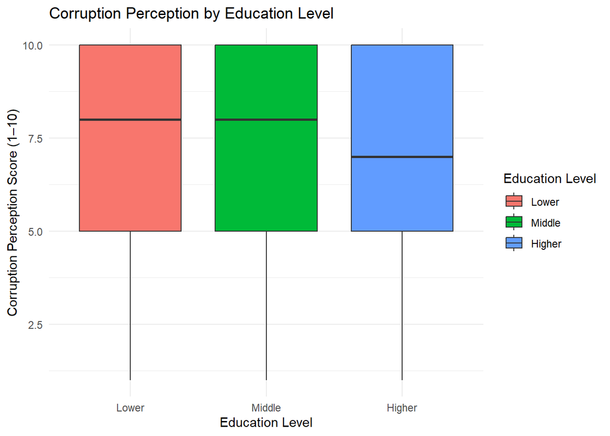

Figure 6: Corruption perception distributions across education levels.

```r
WVS_WB |>
  filter(!is.na(education), !is.na(corruption_perception)) |>
  mutate(education = factor(education,
                            levels = c(1, 2, 3),
                            labels = c("Lower", "Middle", "Higher"))) |>
  ggplot(aes(x = education, y = corruption_perception, fill = education)) +
  geom_boxplot() +
  labs(
    title = "Corruption Perception by Education Level",
    x = "Education Level",
    y = "Corruption Perception Score (1–10)",
    fill = "Education Level"
  ) +
  theme_minimal()
```

```r
edu_data <- WVS_WB |>
  filter(!is.na(education), !is.na(corruption_perception)) |>
  mutate(education = factor(education, levels = c(1, 2, 3),
                            labels = c("Lower", "Middle", "Higher")))

# Group means
edu_data |>
  group_by(education) |>
  summarise(n = n(), mean = mean(corruption_perception))
```

```
# A tibble: 3 × 3
  education     n  mean
  <fct>     <int> <dbl>
1 Lower      5032  7.35
2 Middle     7122  7.20
3 Higher     8594  6.86
```

```r
# Pooled comparison (all respondents together)
lm(corruption_perception ~ education, data = edu_data) |>
  broom::tidy() |>
  filter(str_starts(term, "education"))
```

```
# A tibble: 2 × 5
  term            estimate std.error statistic  p.value
  <chr>              <dbl>     <dbl>     <dbl>    <dbl>
1 educationMiddle   -0.150    0.0504     -2.97 2.96e- 3
2 educationHigher   -0.490    0.0486    -10.1  7.82e-24
```

```r
# Within-country comparison (adds a separate baseline for each country)
lm(corruption_perception ~ education + B_COUNTRY_ALPHA, data = edu_data) |>
  broom::tidy() |>
  filter(str_starts(term, "education"))
```

```
# A tibble: 2 × 5
  term            estimate std.error statistic  p.value
  <chr>              <dbl>     <dbl>     <dbl>    <dbl>
1 educationMiddle    0.314    0.0456      6.88 6.11e-12
2 educationHigher    0.138    0.0465      2.97 2.95e- 3
```

**Interpretation**

- **Generalization:** Pooled across all respondents, highly educated citizens report somewhat lower perceived corruption. However, this difference mostly reflects differences *between countries* and disappears (and slightly reverses) when respondents are compared within the same country.
- **Examples:** Lower and Middle education groups have identical median scores of 8 out of 10, while the Higher group has a median of 7. Mean scores are 7.35 (Lower), 7.20 (Middle), and 6.86 (Higher). In a pooled regression, the Higher group scores 0.49 points below the Lower group (*p* < 0.001). Within countries, however, the Higher group scores 0.14 points *above* the Lower group (*p* = 0.003), and the Middle group 0.31 points above.
- **Exceptions:** The within-country pattern is not uniform. In some countries, such as Canada and New Zealand, higher-educated respondents report less corruption than lower-educated respondents, while in others, such as Kyrgyz Republic and Zimbabwe, they report more.
- **Hypothesis Evaluation: Not Supported once country is accounted for.** The raw pooled gap looks like support for the hypothesis, but it mixes education with national context. Comparing people within the same country, higher education is not associated with lower perceived corruption.

## 8. Key Findings

- **Sample:** 21,187 respondents from 14 countries surveyed in 2020, all matched to World Bank data.
- **Sex:** No difference in perceived corruption (men 7.09, women 7.10).
- **Institutions:** Countries with stronger control of corruption report lower perceived corruption (*r* = −0.69 across 14 countries), though the result rests heavily on three high-control countries.
- **Education:** A pooled gap (higher-educated report less corruption) disappears within countries.
- **Afghanistan:** Rapid but volatile growth through 2013, weak growth afterward, and a contraction of about 21% in 2021.

## 9. Limitations

- **Perceptions, not corruption itself:** The WVS item measures what people believe, not actual corruption levels.
- **Overlapping measures:** The World Bank Control of Corruption indicator is partly built from perception-based sources, so it is not fully independent of the survey item.
- **Small country sample:** Only 14 countries were surveyed in 2020, with just three at the high-control end.
- **Country-level inference:** Results from country averages do not describe individual respondents.
- **Unweighted data:** WVS survey weights were not applied.
- **Coarse education measure:** Education is recoded into only three broad groups.